# MCEU

```python
from adsy.ipython import extended_styles
extended_styles()
```

Toggle Input

Before we get going, some questions for Josh:

- What is an attack graph? Are we essentially trying to "narrow down" an attack graph based on attacker incentives?
- Have you ever heard of the Carneige Mellon CyLab? Ever work with their data?
- What layer of OSI are we working in? Any good self-contained references to learn more about OSI?

# Scenario:

Let's recap what happened last time:

## For the first experiment

Time is discrete (0,1,2,3,4,5...).

We define a window length, $w$.

We define an anomaly threshold, $k$.

We are starting with a fully observable decision process so the "state" at time $t$ consists of the number of messages sent in time $t-1, t-2, t-3...t-w.$ The state also includes whether or not the attacker has infected the subsequent node and whether or not the alarm has went off.

At each time-step here is the sequence of events

- The attacker observes the state.
- He then chooses whether to send a message or not.
- If the attacker does send a malicious message, then 'B' becomes infected with probability, $p$
- with probability $q$, 'A' sends a normal message to 'B'
- Then if the sum of all messages sent from 'A' to 'B' (that is both the normal and malicious messages) in time $t, t-1, t-2,....t-w > k$, then the alarm sounds.
- The attacker receives a reward of 1 if infects 'B' before the alarm sounds.

It turns out that we can solve this problem with policy iteration when $w$ and $k$ are small.

However, even for moderately sized $w$ and $k$, the state space becomes enormous, For example, with $k=w=20$ the number of non-terminal states is $1,554,702,516 > 10^9$. When $w=50$, $k=25$ messages, the number of nonterminal states is $2,172,059,964,211,880,466 > 10^{18}$... and this is only with two nodes!

# Back to continuous time

Now suppose that the attacker can remain in the network forever.

He needs to choose a Poisson rate at which to send messages to the next node

If he infects the next node before the alarm sounds, he receives a reward of 1, otherwise he receives a reward of 0.

Note that we do not need to introduce a discount rate yet since the alarm will eventually sound due to background network traffic which incentives the attacker to send messages at a relatively high rate.

# Memory

Note that when we move to larger nets, if the attacker remembers the times of his previous messages (and those times make up up the "state"), then we still bump up to the issue of an infinite and continuously changing state space. However in continuous time with the attacker's space being Poisson, we might be able to argue that over a large time period, the attacker only needs to know the Poisson rates to get an idea of the number of messages he sent.

# An expected utility experiment

```python
from sft import SFT
from sft_net import SFTNet
import numpy as np
from tools_new import gen_data, get_alarm_time
from matplotlib import pyplot as plt
%matplotlib inline
import time
from scipy.optimize import fmin_bfgs
```

```python
def MCEU(l1, n=1000, T=100, thresh=-5, window=10):
    A = SFT('A', ['normal', 'infected'], ['B'],
      {'B':np.array([[5, 0], [1, l1]])},
       ['clean', 'malicious'], 'external')

    B = SFT('B', ['normal', 'infected'], [],
       {},
       ['clean', 'malicious'], 'internal', pi_st=.05)
    net = SFTNet([A,B])
    successes = 0
    for trial in range(n):
        data = gen_data(T, net, {'A': 'infected', 'B': 'normal'})
        alarm_time =  get_alarm_time(net, data, T, window, thresh)
        #print alarm_time, data[-1]['B']
        if (alarm_time > data[-1]['B']) and (alarm_time > window + 1):
            successes+=1
    return successes
```

```python
EUs = []
start= time.time()
for i in np.arange(0,20,.1):
    #print i
    EUs.append(MCEU(i))
print 'This plot took ', time.time() - start, ' seconds'
```

```
This plot took  187.114773035  seconds
```

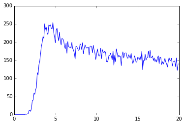

```python
plt.plot(np.arange(0,20,.1), EUs)
```

```python
EUs2 = []
start= time.time()
for i in np.arange(3,6,.05):
    print i
    EUs2.append(MCEU(i))
print 'This plot took ', time.time() - start, ' seconds'
```

[figure not shown]

```python
plt.plot(np.arange(3,6,.05), EUs2)
```

Now, there is a literature on simulation based maximum expected utility, for example:

Eric Jacquier, Michael Johannes, and Nicholas Polson. "Maximum Expected Utility via MCMC". Working Paper, May 2006.

We could also use some sort of (semi)(non) parametric fit to the expected utility function and then maximize that.

Or on the very optimistic side, this could be a spot for contribution.

```python
%%javascript
IPython.load_extensions("calico-spell-check");
```